# Monitoreo de fenología en cultivos de trigo y maíz derivado de datos satelitales Sentinel-2

Proyecto Fondecyt de Iniciación N°11190360

2021-08-11

# Indice

## Área de estudio

#### Puntos de muestreo

Se tienen dos predios experimentales de cultivos maíz y trigo localizados en la localidad de Villa Baviera.

En cada predio se seleccionaron 5 puntos de muestreo y se realizaron 5 campañas en la temporada, donde se cosechó la biomasa de trigo (50 cm2) y maiz (10 plantas)

[interactive chart not shown]

## Biomasa

#### Campañas realizadas

Las cinco campañas realizadas corresponden a las fechas 05-nov., 19-nov., 09-dic., 29-dic., 18-ene.

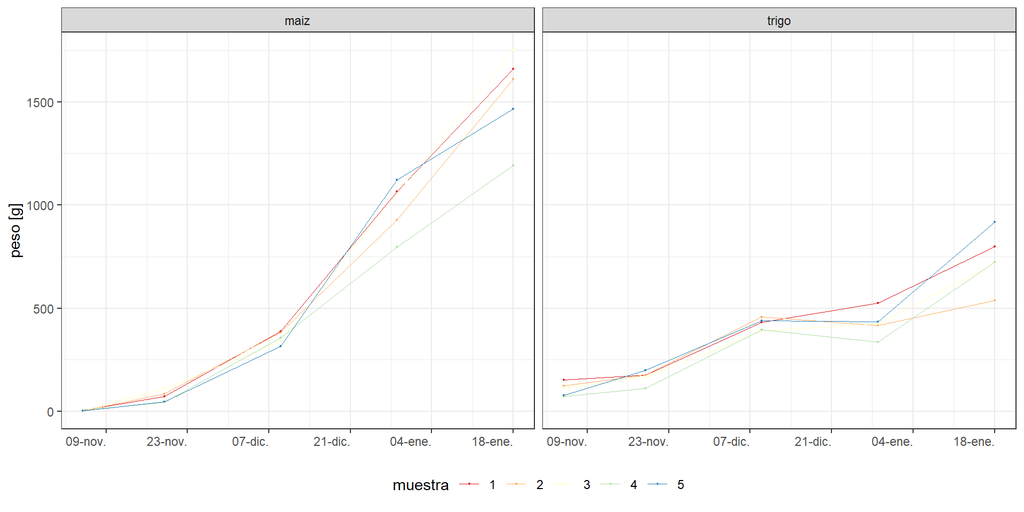

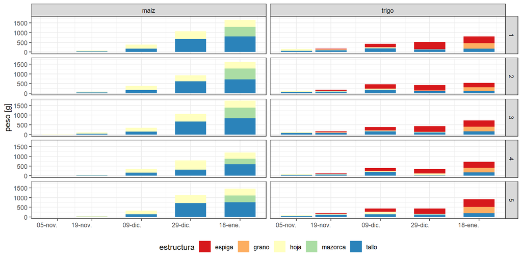

## NDVI

#### Serie temporal de NDVI

El NDVI entrega la informacion del vigor fotosintético de la vegetación. Por lo tanto, el registro temporal de NDVI durante la temporada del cultivo permite determinar su fenología e identificar las principales etapas de su desarrollo.

Las principales etapas del desarrollo del cultivo son:

- Fecha de inicio del crecimiento de la temporada (t0)
- Fecha del mayor tasa de crecimiento (x0)
- La longitud de la meseta de madurez (L)
- La fecha de finalización de la temporada de crecimiento (t3)

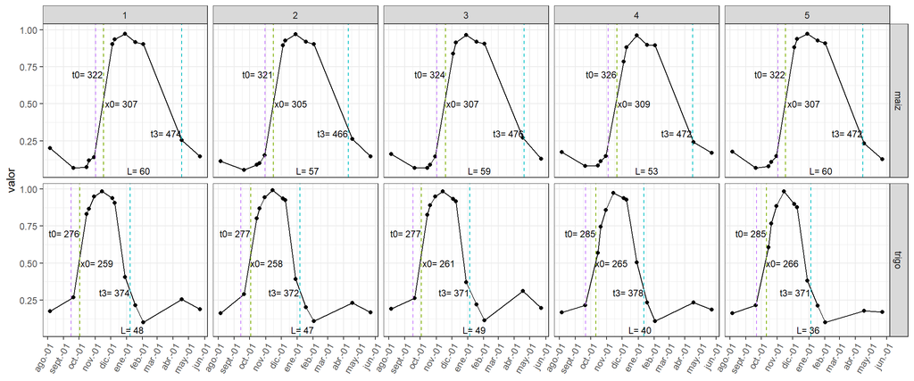

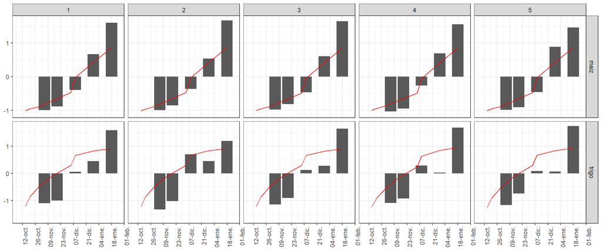

Registro normalizado de biomasa (columnas) y serie temporal de NDVI (linea roja)

#### Datos raster

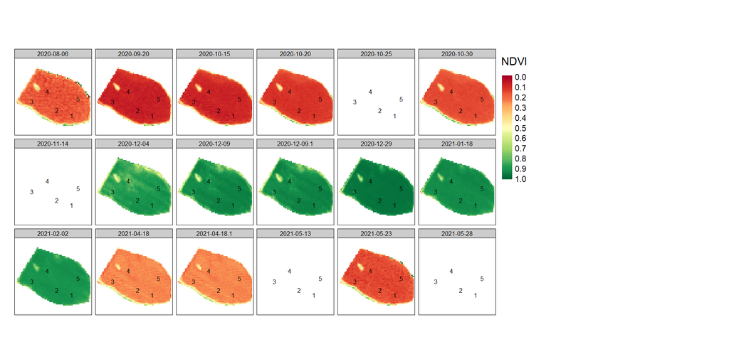

Serie temporal de imagenes de NDVI en predio de maíz

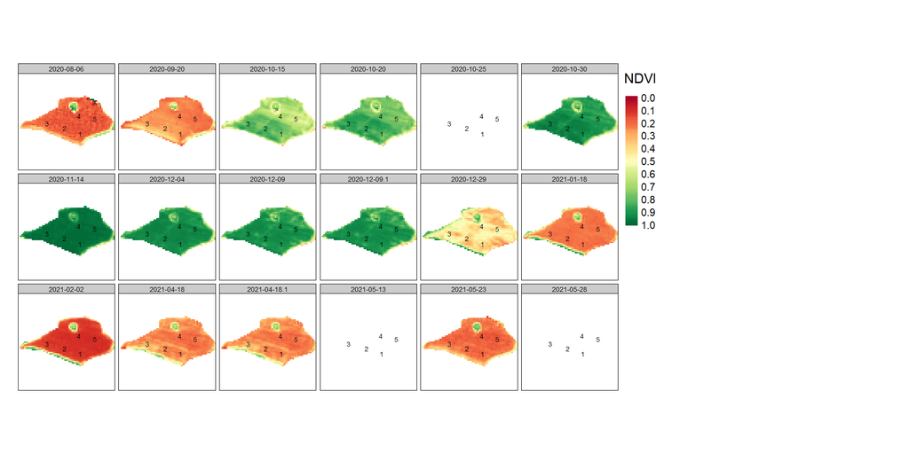

Serie temporal de imagenes de NDVI en predio de trigo

## Área Foliar

#### Serie temporal de LAI

El indice de area foliar es la cantidad de superficie foliar (m2) que se encuentra en una determinada superficie (m2)

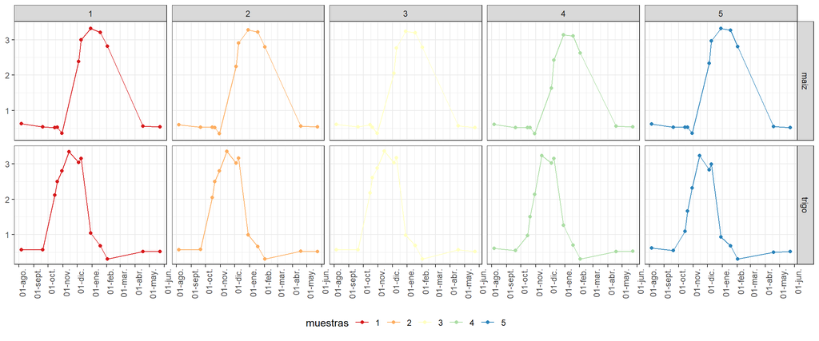

#### Datos raster

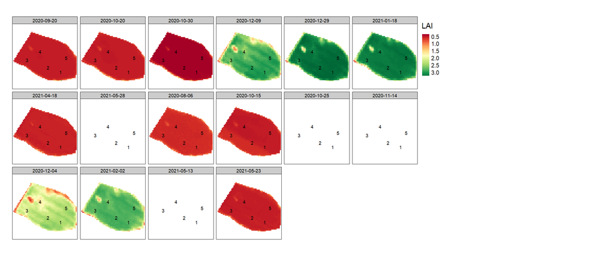

Serie temporal de imagenes de LAI en predio de maíz

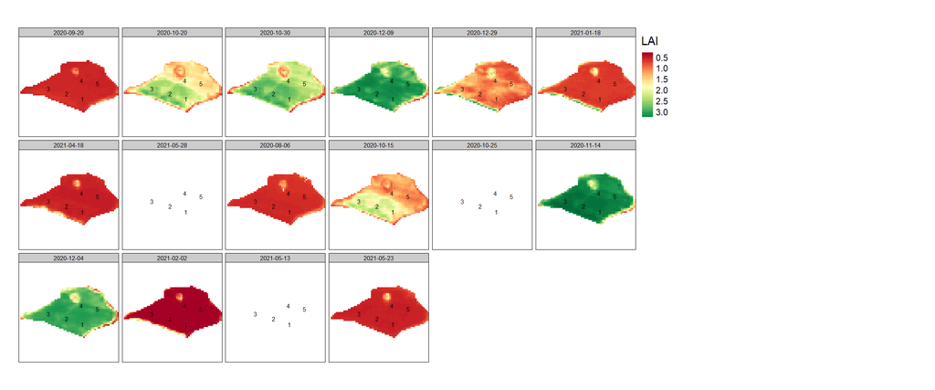

Serie temporal de imagenes de LAI en predio de trigo

## Meteorología

#### Registro semanal

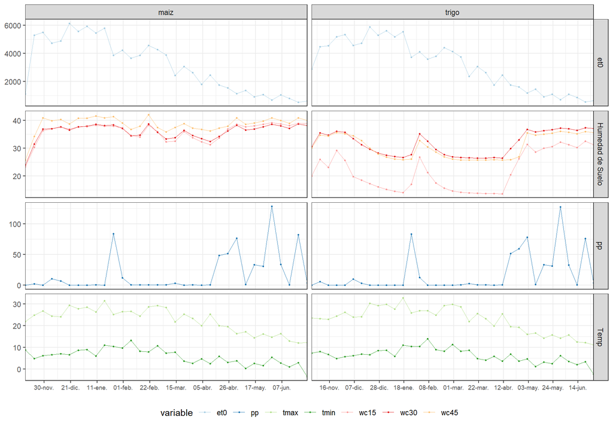